# Case Study 1: How Does a Bike-Share Navigate Speedy Success?

Zarrief Sofea

2023-11-18

### *Scenario*

You are a junior data analyst working in the marketing analyst team at Cyclistic, a bike-share company in Chicago. The director of marketing believes the company’s future success depends on maximizing the number of annual memberships. Therefore, your team wants to understand how casual riders and annual members use Cyclistic bikes differently. From these insights, your team will design a new marketing strategy to convert casual riders into annual members. But first, Cyclistic executives must approve your recommendations, so they must be backed up with compelling data insights and professional data visualizations.

Cyclistic categorize it users into two categories:

- casual : Customer who purchase single ride or full-day passes.
- members: Customer who purchase annual membership.

### *Business Question*

Three questions will guide the future marketing program:

- How do annual members and casual riders use Cyclistic bikes differently?
- Why would casual riders buy Cyclistic annual memberships?
- How can Cyclistic use digital media to influence casual riders to become members?

### **Part 1: Load data**

Setting up R envirnment

```r
library(tidyverse)
```

```r
library(lubridate)
library(tidyr)
library(dplyr)
library(ggplot2)
library(patchwork)
```

```r
setwd("C:/Users/zarri/OneDrive/Documents/Coursera/Case1/raw_data")

df1 <- list.files("C:/Users/zarri/OneDrive/Documents/Coursera/Case1/raw_data") %>%
  lapply(read_csv) %>%
  bind_rows
```

Preview dataset

```r
summary(df1)
```

```
##    ride_id          rideable_type        started_at
##  Length:2390459     Length:2390459     Min.   :2023-01-01 00:01:58.0
##  Class :character   Class :character   1st Qu.:2023-03-28 06:35:48.5
##  Mode  :character   Mode  :character   Median :2023-05-08 17:18:47.0
##                                        Mean   :2023-04-27 04:49:19.5
##                                        3rd Qu.:2023-06-05 15:41:32.5
##                                        Max.   :2023-06-30 23:59:56.0
##
##     ended_at                      start_station_name start_station_id
##  Min.   :2023-01-01 00:02:41.00   Length:2390459     Length:2390459
##  1st Qu.:2023-03-28 06:46:49.00   Class :character   Class :character
##  Median :2023-05-08 17:31:21.00   Mode  :character   Mode  :character
##  Mean   :2023-04-27 05:06:45.39
##  3rd Qu.:2023-06-05 15:59:57.00
##  Max.   :2023-07-10 20:26:44.00
##
##  end_station_name   end_station_id       start_lat       start_lng
##  Length:2390459     Length:2390459     Min.   :41.64   Min.   :-87.87
##  Class :character   Class :character   1st Qu.:41.88   1st Qu.:-87.66
##  Mode  :character   Mode  :character   Median :41.90   Median :-87.64
##                                        Mean   :41.90   Mean   :-87.65
##                                        3rd Qu.:41.93   3rd Qu.:-87.63
##                                        Max.   :42.07   Max.   :-87.52
##
##     end_lat         end_lng       member_casual
##  Min.   : 0.00   Min.   :-88.16   Length:2390459
##  1st Qu.:41.88   1st Qu.:-87.66   Class :character
##  Median :41.90   Median :-87.64   Mode  :character
##  Mean   :41.90   Mean   :-87.65
##  3rd Qu.:41.93   3rd Qu.:-87.63
##  Max.   :42.11   Max.   :  0.00
##  NA's   :2460    NA's   :2460
```

```r
colnames(df1)
```

```
##  [1] "ride_id"            "rideable_type"      "started_at"
##  [4] "ended_at"           "start_station_name" "start_station_id"
##  [7] "end_station_name"   "end_station_id"     "start_lat"
## [10] "start_lng"          "end_lat"            "end_lng"
## [13] "member_casual"
```

```r
head(df1)
```

```
## # A tibble: 6 × 13
##   ride_id          rideable_type started_at          ended_at
##   <chr>            <chr>         <dttm>              <dttm>
## 1 F96D5A74A3E41399 electric_bike 2023-01-21 20:05:42 2023-01-21 20:16:33
## 2 13CB7EB698CEDB88 classic_bike  2023-01-10 15:37:36 2023-01-10 15:46:05
## 3 BD88A2E670661CE5 electric_bike 2023-01-02 07:51:57 2023-01-02 08:05:11
## 4 C90792D034FED968 classic_bike  2023-01-22 10:52:58 2023-01-22 11:01:44
## 5 3397017529188E8A classic_bike  2023-01-12 13:58:01 2023-01-12 14:13:20
## 6 58E68156DAE3E311 electric_bike 2023-01-31 07:18:03 2023-01-31 07:21:16
## # ℹ 9 more variables: start_station_name <chr>, start_station_id <chr>,
## #   end_station_name <chr>, end_station_id <chr>, start_lat <dbl>,
## #   start_lng <dbl>, end_lat <dbl>, end_lng <dbl>, member_casual <chr>
```

```r
glimpse(df1)
```

```
## Rows: 2,390,459
## Columns: 13
## $ ride_id            <chr> "F96D5A74A3E41399", "13CB7EB698CEDB88", "BD88A2E670…
## $ rideable_type      <chr> "electric_bike", "classic_bike", "electric_bike", "…
## $ started_at         <dttm> 2023-01-21 20:05:42, 2023-01-10 15:37:36, 2023-01-…
## $ ended_at           <dttm> 2023-01-21 20:16:33, 2023-01-10 15:46:05, 2023-01-…
## $ start_station_name <chr> "Lincoln Ave & Fullerton Ave", "Kimbark Ave & 53rd …
## $ start_station_id   <chr> "TA1309000058", "TA1309000037", "RP-005", "TA130900…
## $ end_station_name   <chr> "Hampden Ct & Diversey Ave", "Greenwood Ave & 47th …
## $ end_station_id     <chr> "202480", "TA1308000002", "599", "TA1308000002", "T…
## $ start_lat          <dbl> 41.92407, 41.79957, 42.00857, 41.79957, 41.79957, 4…
## $ start_lng          <dbl> -87.64628, -87.59475, -87.69048, -87.59475, -87.594…
## $ end_lat            <dbl> 41.93000, 41.80983, 42.03974, 41.80983, 41.80983, 4…
## $ end_lng            <dbl> -87.64000, -87.59938, -87.69941, -87.59938, -87.599…
## $ member_casual      <chr> "member", "member", "casual", "member", "member", "…
```

### **Part 2: Data Cleaning**

Checking typo in categorical col.

```r
unique(df1$rideable_type)
```

```
## [1] "electric_bike" "classic_bike"  "docked_bike"
```

```r
unique(df1$member_casual)
```

```
## [1] "member" "casual"
```

Checking missing values

```r
emptyCells <- sapply(df1, function(x)
  sum(is.na(x)))
print(emptyCells)
```

```
##            ride_id      rideable_type         started_at           ended_at
##                  0                  0                  0                  0
## start_station_name   start_station_id   end_station_name     end_station_id
##             357417             357549             380963             381104
##          start_lat          start_lng            end_lat            end_lng
##                  0                  0               2460               2460
##      member_casual
##                  0
```

Checking duplicate rows

```r
duplicates <- df1[duplicated(df1), ]

duplicate_counts <- table(df1[duplicated(df1), ])

duplicates
```

```
## # A tibble: 0 × 13
## # ℹ 13 variables: ride_id <chr>, rideable_type <chr>, started_at <dttm>,
## #   ended_at <dttm>, start_station_name <chr>, start_station_id <chr>,
## #   end_station_name <chr>, end_station_id <chr>, start_lat <dbl>,
## #   start_lng <dbl>, end_lat <dbl>, end_lng <dbl>, member_casual <chr>
```

```r
duplicate_counts
```

```
## < table of extent 0 x 0 x 0 x 0 x 0 x 0 x 0 x 0 x 0 x 0 x 0 x 0 x 0 >
```

Change datetimes col. types to format that we want.

```r
df1 <- df1 %>%
  mutate(started_at = as_datetime(started_at)) %>%
  mutate(ended_at = as_datetime(ended_at))
```

Now that we get our desired data types, we can just use subtraction to get ride duration

Now create new. col named “ride_length” (subtraction operator method for produces durations)

```r
df2 <- df1 %>%
  mutate(ride_length = difftime(ended_at, started_at, units = "mins"))
```

Convert ride_length to numeric format

```r
df2$ride_length <-
  as.numeric(as.character(df2$ride_length))
is.numeric(df2$ride_length) #returns TRUE if ride_length is already numeric
```

```
## [1] TRUE
```

Checking for the min and max value in ride_length column

```r
max(df2$ride_length)
```

```
## [1] 33603.73
```

```r
min(df2$ride_length) #since we got negative mins we must remove it
```

```
## [1] -60.25
```

Removing bad ride_length data (ride length must be at least 1 min but not more than 24 hours or 1440 minutes.)

```r
df2 = df2 %>%
  filter(between(ride_length, 1, 1440))
bad_data <- nrow(df1) - nrow(df2)
paste0("There are a total of ", bad_data , " bad data removed ")
```

```
## [1] "There are a total of 75011 bad data removed "
```

Lastly create col named “hour_start”, “month”,“day_of_week”

```r
df2$day_of_week <- weekdays(as.Date(df2$started_at))

df2 <- df2 %>%
  mutate(
    hour_start = hour(started_at),
    month = month(started_at, label = T, abbr = F),
    day_of_week = wday(started_at, label = T, abbr = F))
```

Checking the cleaned data

```r
glimpse(df2)
```

```
## Rows: 2,315,448
## Columns: 17
## $ ride_id            <chr> "F96D5A74A3E41399", "13CB7EB698CEDB88", "BD88A2E670…
## $ rideable_type      <chr> "electric_bike", "classic_bike", "electric_bike", "…
## $ started_at         <dttm> 2023-01-21 20:05:42, 2023-01-10 15:37:36, 2023-01-…
## $ ended_at           <dttm> 2023-01-21 20:16:33, 2023-01-10 15:46:05, 2023-01-…
## $ start_station_name <chr> "Lincoln Ave & Fullerton Ave", "Kimbark Ave & 53rd …
## $ start_station_id   <chr> "TA1309000058", "TA1309000037", "RP-005", "TA130900…
## $ end_station_name   <chr> "Hampden Ct & Diversey Ave", "Greenwood Ave & 47th …
## $ end_station_id     <chr> "202480", "TA1308000002", "599", "TA1308000002", "T…
## $ start_lat          <dbl> 41.92407, 41.79957, 42.00857, 41.79957, 41.79957, 4…
## $ start_lng          <dbl> -87.64628, -87.59475, -87.69048, -87.59475, -87.594…
## $ end_lat            <dbl> 41.93000, 41.80983, 42.03974, 41.80983, 41.80983, 4…
## $ end_lng            <dbl> -87.64000, -87.59938, -87.69941, -87.59938, -87.599…
## $ member_casual      <chr> "member", "member", "casual", "member", "member", "…
## $ ride_length        <dbl> 10.850000, 8.483333, 13.233333, 8.766667, 15.316667…
## $ day_of_week        <ord> Saturday, Tuesday, Monday, Sunday, Thursday, Tuesda…
## $ hour_start         <int> 20, 15, 7, 10, 13, 7, 21, 10, 20, 16, 17, 17, 19, 2…
## $ month              <ord> January, January, January, January, January, Januar…
```

### **Part 3: Analyze**

**Calculating for the mean and median values of ride_length**

```r
mean_ridelength_member <-
  mean(df2$ride_length[df2$member_casual == "member"], na.rm = TRUE)

paste0("Members mean length of ride is ", mean_ridelength_member)
```

```
## [1] "Members mean length of ride is 12.0719159733832"
```

```r
mean_ridelength_casual <-
  mean(df2$ride_length[df2$member_casual == "casual"], na.rm = TRUE)

paste0("Casuals mean length of ride is ", mean_ridelength_casual)
```

```
## [1] "Casuals mean length of ride is 21.1192726215677"
```

**Find the overall median of ride length as well as among annual members & casual riders.**

```r
median_ridelength_member <-
  median(df2$ride_length[df2$member_casual == "member"], na.rm = TRUE)

paste0("Members median length of ride is ", median_ridelength_member)
```

```
## [1] "Members median length of ride is 8.46666666666667"
```

```r
median_ridelength_casual <-
  median(df2$ride_length[df2$member_casual == "casual"], na.rm = TRUE)

paste0("Casuals median length of ride is ", median_ridelength_casual)
```

```
## [1] "Casuals median length of ride is 12"
```

**Find the overall maximum of ride length as well as among annual members & casual riders**

```r
max_ridelength_member <-
  max(df2$ride_length[df2$member_casual == "member"], na.rm = TRUE)

paste0("Members max length of ride is ", max_ridelength_member)
```

```
## [1] "Members max length of ride is 1433.3"
```

```r
max_ridelength_casual <-
  max(df2$ride_length[df2$member_casual == "casual"], na.rm = TRUE)

paste0("Casuals max length of ride is ", max_ridelength_casual)
```

```
## [1] "Casuals max length of ride is 1439.05"
```

**Find the overall manimum of ride length as well as among annual members & casual riders**

```r
min_ridelength_member <-
  min(df2$ride_length[df2$member_casual == "member"], na.rm = TRUE)

paste0("Members min length of ride is ", min_ridelength_member)
```

```
## [1] "Members min length of ride is 1"
```

```r
min_ridelength_casual <-
  min(df2$ride_length[df2$member_casual == "casual"], na.rm = TRUE)

paste0("Casuals min length of ride is ", min_ridelength_casual)
```

```
## [1] "Casuals min length of ride is 1"
```

**Finding 1**

Casual riders have greater mean and median ride lengths than annual members, while having similar minimum and maximum ride lengths.

**Total number of rides among annual members and casual riders**

```r
customer_totalrides <- df2 %>%
  group_by(member_casual) %>%
  dplyr::summarise(number_of_rides = n())
customer_totalrides
```

```
## # A tibble: 2 × 2
##   member_casual number_of_rides
##   <chr>                   <int>
## 1 casual                 802118
## 2 member                1513330
```

**Finding 2**

Annual members have the highest number of rides compared to casual riders from January 2023 - June 2023

**Most Popular Starting Hours among annual members and casual riders**

```r
peak_hour <-df2 %>%
  group_by(member_casual, hour_start) %>%
  dplyr::summarise(number_of_rides = n(), .groups = "drop")
peak_hour
```

```
## # A tibble: 48 × 3
##    member_casual hour_start number_of_rides
##    <chr>              <int>           <int>
##  1 casual                 0           13294
##  2 casual                 1            8314
##  3 casual                 2            5055
##  4 casual                 3            2662
##  5 casual                 4            2105
##  6 casual                 5            4296
##  7 casual                 6           11757
##  8 casual                 7           20656
##  9 casual                 8           27485
## 10 casual                 9           26661
## # ℹ 38 more rows
```

**Finding 3**

**Most Popular Day of the Week among annual members and casual riders**

```r
peak_day <-df2 %>%
  group_by(member_casual, day_of_week) %>%
  dplyr::summarise(number_of_rides = n(), .groups = "drop")
peak_day
```

```
## # A tibble: 14 × 3
##    member_casual day_of_week number_of_rides
##    <chr>         <ord>                 <int>
##  1 casual        Sunday               122279
##  2 casual        Monday                90368
##  3 casual        Tuesday               94119
##  4 casual        Wednesday            102071
##  5 casual        Thursday             110099
##  6 casual        Friday               125620
##  7 casual        Saturday             157562
##  8 member        Sunday               161559
##  9 member        Monday               201811
## 10 member        Tuesday              242030
## 11 member        Wednesday            249644
## 12 member        Thursday             246649
## 13 member        Friday               223626
## 14 member        Saturday             188011
```

```r
peak_day_ridelength <-df2 %>%
  group_by(member_casual, day_of_week) %>%
  dplyr::summarise(mean_ridelength = mean(ride_length), .groups = "drop")
peak_day_ridelength
```

```
## # A tibble: 14 × 3
##    member_casual day_of_week mean_ridelength
##    <chr>         <ord>                 <dbl>
##  1 casual        Sunday                 24.8
##  2 casual        Monday                 20.7
##  3 casual        Tuesday                18.3
##  4 casual        Wednesday              18.0
##  5 casual        Thursday               18.7
##  6 casual        Friday                 20.6
##  7 casual        Saturday               24.3
##  8 member        Sunday                 13.4
##  9 member        Monday                 11.4
## 10 member        Tuesday                11.5
## 11 member        Wednesday              11.6
## 12 member        Thursday               11.6
## 13 member        Friday                 12.0
## 14 member        Saturday               13.7
```

**Finding 4**

1. Annual members have the most number of rides during Wednesdays and Thursdays, while casual riders have less and mostly prefer to ride bikes during weekends.
2. Casual riders have a significantly longer rides than annual members in all days of the week, with Sunday being the longest of the week.

**Most Popular Month among annual members and casual riders**

```r
peak_month <-df2 %>%
  group_by(member_casual, month) %>%
  dplyr::summarise(number_of_rides = n(), .groups = "drop")
peak_month
```

```
## # A tibble: 12 × 3
##    member_casual month    number_of_rides
##    <chr>         <ord>              <int>
##  1 casual        January            38749
##  2 casual        February           41734
##  3 casual        March              60152
##  4 casual        April             142226
##  5 casual        May               226892
##  6 casual        June              292365
##  7 member        January           145246
##  8 member        February          142601
##  9 member        March             189289
## 10 member        April             269042
## 11 member        May               359461
## 12 member        June              407691
```

```r
peak_month_ridelength <-df2 %>%
  group_by(member_casual, month) %>%
  dplyr::summarise(mean_ride_length = mean(ride_length), .groups = "drop")
peak_month_ridelength
```

```
## # A tibble: 12 × 3
##    member_casual month    mean_ride_length
##    <chr>         <ord>               <dbl>
##  1 casual        January              14.1
##  2 casual        February             16.5
##  3 casual        March                15.8
##  4 casual        April                21.4
##  5 casual        May                  22.8
##  6 casual        June                 22.4
##  7 member        January              10.4
##  8 member        February             10.8
##  9 member        March                10.6
## 10 member        April                11.9
## 11 member        May                  12.9
## 12 member        June                 13.2
```

**Finding 5**

1. The month of June records the highest number of rides for both type of membership
2. The month of June record the longest rides of members while the month of May is the longest for casual riders

### **Part 4: Data Vizualization**

**Visualize the mean and median values of ride_length of between customer type**

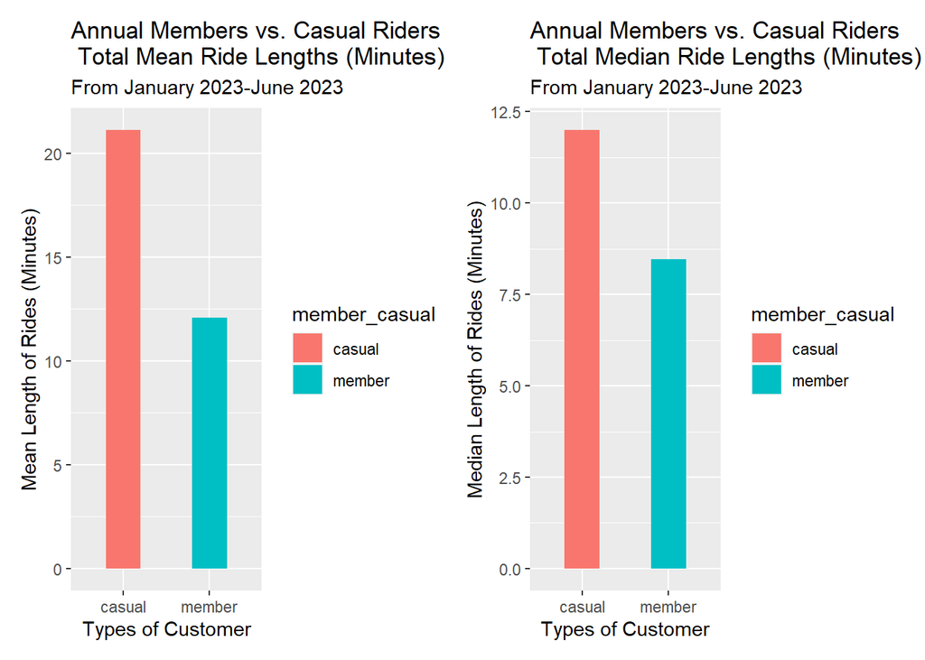

```r
chart1 <-
  df2 %>%
  group_by(member_casual) %>%
  dplyr::summarise(mean_ride_length = mean(ride_length),.groups = "drop") %>%
  ggplot(aes(x = member_casual,
             y = mean_ride_length,
             fill = member_casual)) +
  geom_col(width = 0.4, position = position_dodge(width = 0.5))+
  ggtitle("Annual Members vs. Casual Riders\n Total Mean Ride Lengths (Minutes)")+
   labs(subtitle = "From January 2023-June 2023",
    x = "Types of Customer",
    y = "Mean Length of Rides (Minutes)")


chart2 <-
  df2 %>%
  group_by(member_casual) %>%
  dplyr::summarise(median_ride_length = median(ride_length),.groups = "drop") %>%
  ggplot(aes(x = member_casual,
             y = median_ride_length,
             fill = member_casual)) +
  geom_col(width = 0.4, position = position_dodge(width = 0.5))+
  ggtitle("Annual Members vs. Casual Riders\n Total Median Ride Lengths (Minutes)")+
     labs(subtitle = "From January 2023-June 2023",
    x = "Types of Customer",
    y = "Median Length of Rides (Minutes)")



chart1 + chart2
```

**Visualize the relation between customers type and readable type using ggplot to see each customer bike preferences and also to know which ride type is used more often**

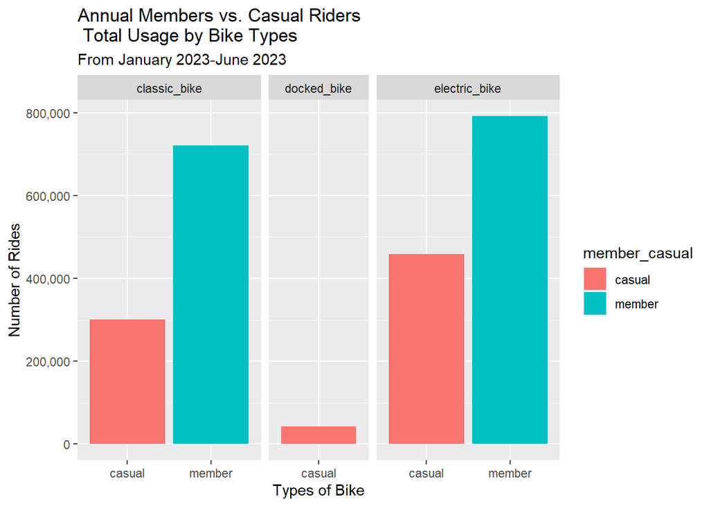

```r
chart3 <-
  df2 %>%
    group_by(member_casual,rideable_type) %>%
    dplyr::summarise(number_of_rides = n(), .groups = "drop") %>%
    ggplot(aes(x=member_casual,y=number_of_rides,fill=member_casual))+
    geom_col(position = "dodge")+
    scale_y_continuous(labels = scales::comma)+
    ggtitle("Annual Members vs. Casual Riders\n Total Usage by Bike Types") +
  labs(subtitle = "From January 2023-June 2023",
    x = "Types of Bike",
    y = "Number of Rides")+
    facet_grid(cols = vars(rideable_type),
      scales = "free_x",
      space = "free_x")

chart3
```

**Visualizing the number of rides each customer type made every month**

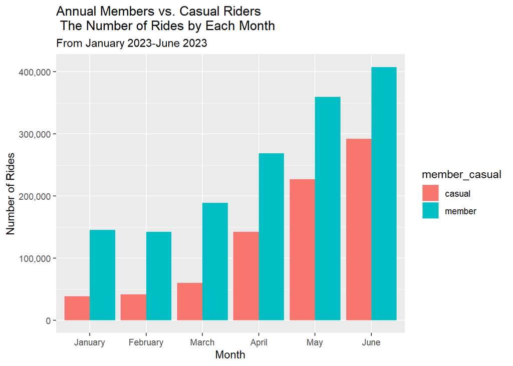

```r
chart9 <- df2 %>%
  group_by(member_casual, month) %>%
  summarise(number_of_rides = n()
            ,average_duration = mean(ride_length)) %>%
  arrange(member_casual, month)  %>%
  ggplot(aes(x = month, y = number_of_rides, fill = member_casual)) +
  geom_col(position = "dodge") +
  scale_y_continuous(labels = scales::comma)+
  ggtitle("Annual Members vs. Casual Riders\n The Number of Rides by Each Month")+
  labs(subtitle = "From January 2023-June 2023",
    x = "Month",
    y = "Number of Rides")
chart9
```

**Visualizing the number of rides each customer type made every day**

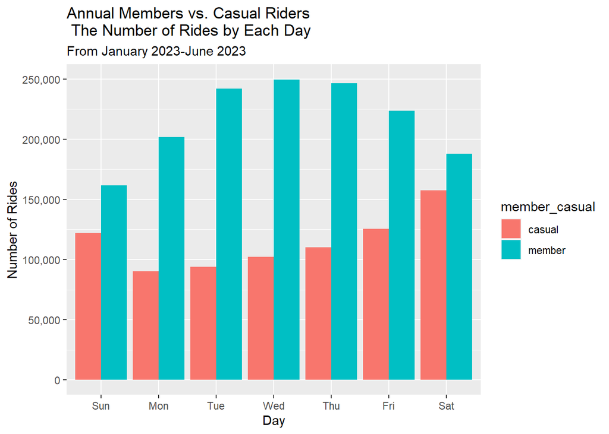

```r
chart10 <- df2 %>%
  mutate(weekday = wday(started_at, label = TRUE)) %>%
  group_by(member_casual, weekday) %>%
  summarise(number_of_rides = n()
            ,average_duration = mean(ride_length)) %>%
  arrange(member_casual, weekday)  %>%
  ggplot(aes(x = weekday, y = number_of_rides, fill = member_casual)) +
  geom_col(position = "dodge")+
  scale_y_continuous(labels = scales::comma)+
  ggtitle("Annual Members vs. Casual Riders\n The Number of Rides by Each Day")+
    labs(subtitle = "From January 2023-June 2023",
    x = "Day",
    y = "Number of Rides")
chart10
```

**Visualizing the number of rides each customer type made at every hour of the day**

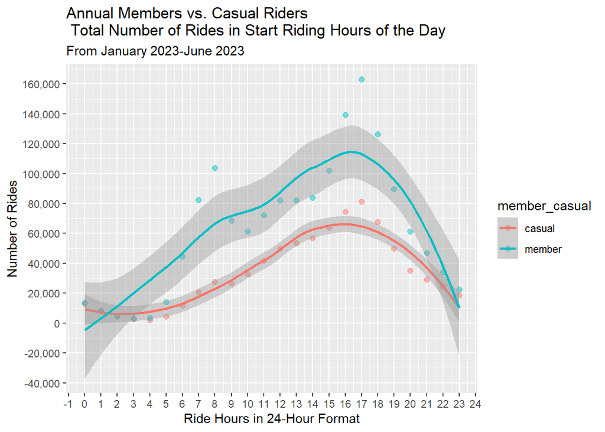

```r
chart4 <- df2 %>%
  group_by(member_casual, hour_start) %>%
  dplyr::summarise(number_of_rides = n(), .groups = "drop") %>%
  ggplot(aes(x = hour_start, y = number_of_rides, col = member_casual)) + geom_point (alpha = 0.5, size = 2) +
  scale_y_continuous(n.breaks = 12, labels = scales::comma) +
  scale_x_continuous(n.breaks = 24) +
  geom_smooth()+
  ggtitle("Annual Members vs. Casual Riders\n Total Number of Rides in Start Riding Hours of the Day")+
    labs(subtitle = "From January 2023-June 2023",
    x = "Ride Hours in 24-Hour Format",
    y = "Number of Rides")

chart4
```

**Vizualize the total number of rides segmented by days**

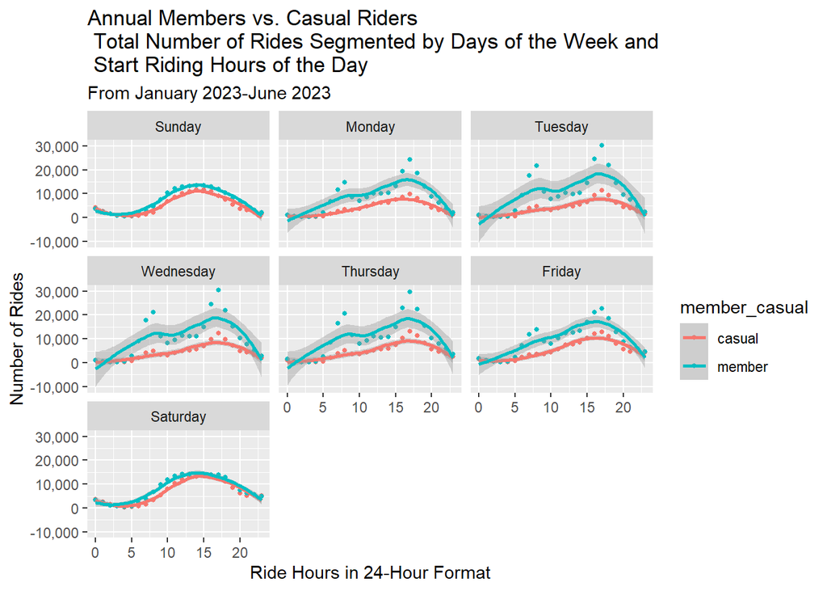

```r
chart5 <- df2 %>%
  group_by(member_casual, hour_start, day_of_week) %>%
  dplyr::summarise(number_of_rides = n(), .groups = "drop") %>%
  ggplot(aes(x = hour_start, y = number_of_rides, col = member_casual)) + geom_point (size = 1) +
  scale_y_continuous(labels = scales::comma) +
  ggtitle("Annual Members vs. Casual Riders\n Total Number of Rides Segmented by Days of the Week and\n Start Riding Hours of the Day")+
  labs(subtitle = "From January 2023-June 2023",
    x = "Ride Hours in 24-Hour Format",
    y = "Number of Rides")+
  facet_wrap(.~day_of_week)+
  geom_smooth()

chart5
```

**Visualizing the average ride length of the customers types each month,day and hour**

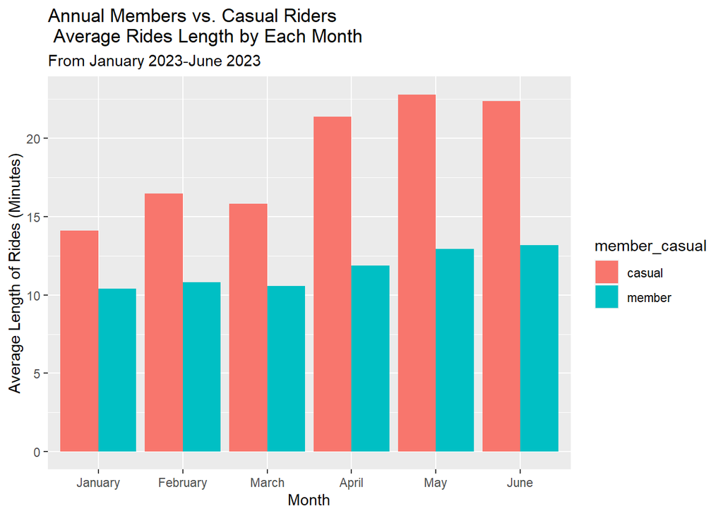

```r
chart6 <- df2 %>%
  group_by(member_casual, month) %>%
  summarise(number_of_rides = n()
            ,average_duration = mean(ride_length)) %>%
  arrange(member_casual, month)  %>%
  ggplot(aes(x = month, y = average_duration, fill = member_casual))+
  geom_col(position = "dodge")+
  ggtitle("Annual Members vs. Casual Riders\n Average Rides Length by Each Month")+
  labs(subtitle = "From January 2023-June 2023",
    x = "Month",
    y = "Average Length of Rides (Minutes)")
chart6
```

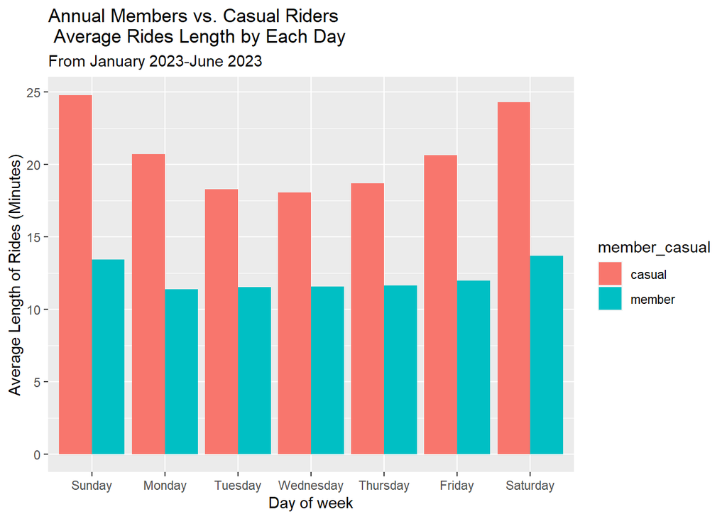

```r
chart7 <- df2 %>%
  group_by(member_casual, day_of_week) %>%
  summarise(number_of_rides = n()
            ,average_duration = mean(ride_length)) %>%
  arrange(member_casual, day_of_week)  %>%
  ggplot(aes(x = day_of_week, y = average_duration, fill = member_casual))+
  geom_col(position = "dodge")+
  ggtitle("Annual Members vs. Casual Riders\n Average Rides Length by Each Day")+
  labs(subtitle = "From January 2023-June 2023",
    x = "Day of week",
    y = "Average Length of Rides (Minutes)")
  chart7
```

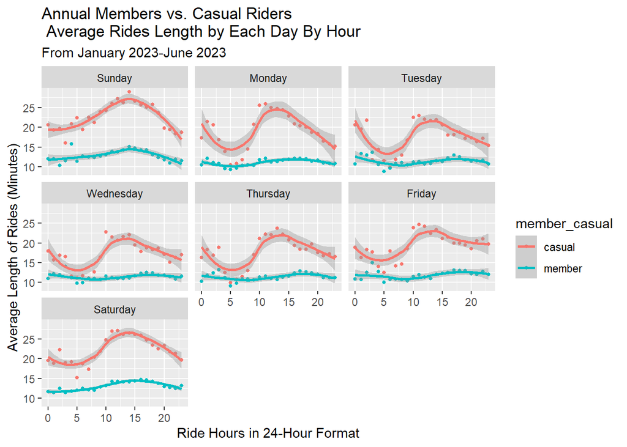

```r
chart8 <- df2 %>%
  group_by(member_casual, hour_start, day_of_week) %>%
  dplyr::summarise(number_of_rides = n(),
                   average_duration = mean(ride_length), .groups = "drop") %>%
  ggplot(aes(x = hour_start, y = average_duration, col = member_casual)) + geom_point (size = 1)+
  ggtitle("Annual Members vs. Casual Riders\n Average Rides Length by Each Day By Hour")+
    labs(subtitle = "From January 2023-June 2023",
    x = "Ride Hours in 24-Hour Format",
    y = "Average Length of Rides (Minutes)")+
  facet_wrap(.~day_of_week)+
  geom_smooth()


chart8
```

### **Part 5: Conclusion**

**Overall Findings**

1. Casual riders have greater mean and median ride lengths than annual members, while having similar minimum and maximum ride lengths. The Annual members have the highest number of rides, compared to casual members. Annual members seems to prefer classic and electric bikes, while casual riders mostly prefer electric bikes. It also showed that the docked bikes are only being used by casual members.
2. The number of rides from both users increases at Chicago from May to June, probably because of warm seasons. It can be seen that the number of rides made by the annual members is more on weekdays while the casual users made more trips on weekends. This probably the annual members subscribes the annual plan as platform to commutes to works while casual members use the service for leisure during weekends.
3. Most popular hour to cycle for both annual members and casual riders are in between 4PM and 6PM, with the peak time for riding bikes being at 5PM. Casual riders have a significantly longer rides than annual members in all days of the week, with Sunday being the longest of the week.

**Recommendations**

1. Cyclistic could offer incentives to both casual and annual riders, such as:
- Discounts for longer rides
- Complimentary trips
- Loyalty programs
- Special discounts
2. To persuade casual passengers to sign up as annual members, Cyclistic could focus on:
- Discounts or incentives during peak times (4PM to 6PM)
- Focusing on weekends and months with the longest and most number of rides (May and June)
3. Cyclistic could also invest in research and development for electric bikes, as well as focus on providing electric and classic bikes to casual and annual riders.

**Further Analysis**

1. More data should be collected such as demographic & weather data to enhance the result.